# Data Udacity

The smallest value is 0.33, the highest is 2, the median is 0.62, the average 0.6581, the 3rd quantile 0.73. This means that the maximum value of 2 is a severe outlier.

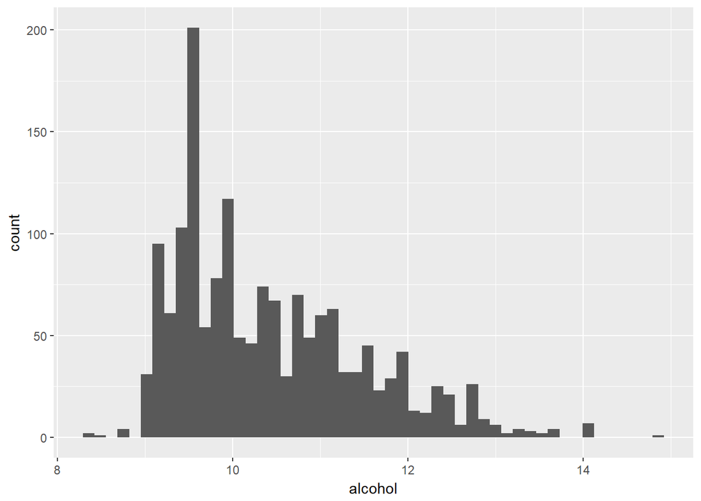

The **alcohol** value in wine is not necessarily a quality feature. However, alcohol has an influence on the taste. A higher alcohol content usually provides a fuller, more intense aroma. The fermentation of wines with a low alcohol content was usually stopped early, so that more residual sugar often remains in the wine. Say: The wine is usually sweeter. Often wine has an alcohol value between 9 and 11 percent. In our data set, the average alcohol content is 10.42 percent. The median is 10.20 percent. The lowest value is 8.4 percent, the highest 14.9 percent.

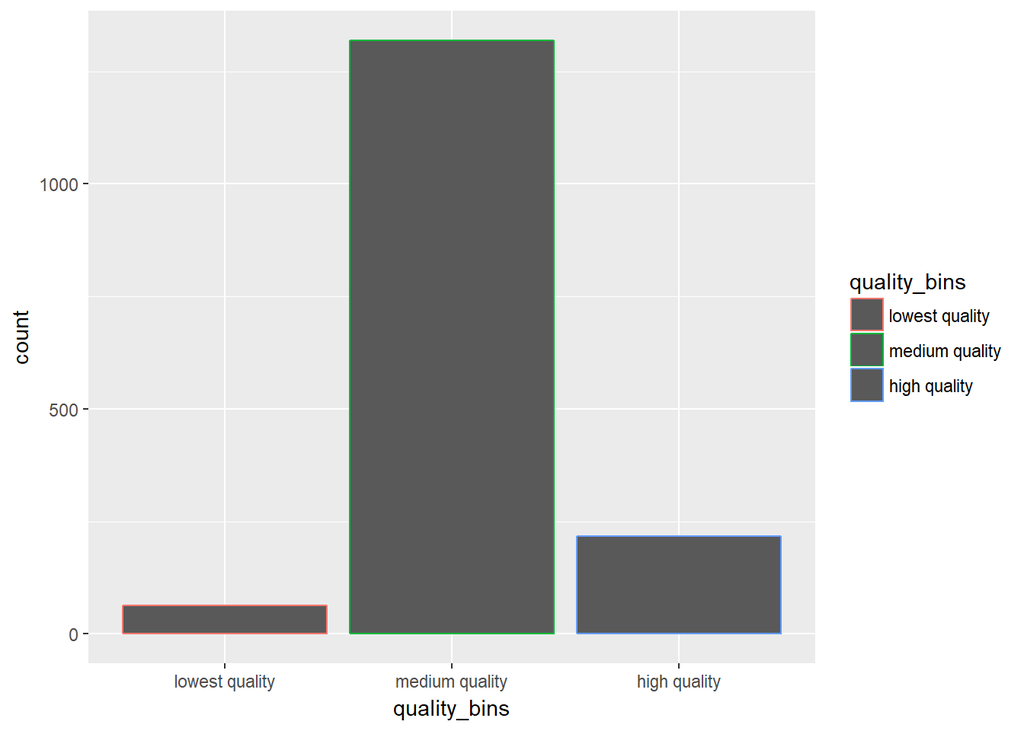

```
## lowest quality medium quality   high quality
##             63           1319            217
```

For further analysis we introduce a **new variable here: quality_bins**. Here the wines are classified according to quality levels in three categories: lowest quality (levels 1 to 4), medium quality (levels 5 and 6) and highest quality (levels 7 to 10). As can be seen in the plot, the majority of our tested wines (1319 samples) are of medium quality, the category “highest quality” includes 217 wines, 63 samples are of only low quality.

# Univariate Analysis

In the dataset we find many variables whose values can influence the quality of a wine. However, even experts have different points of view as to which values and at what level make up a good wine. The bottom line is that it is a combination of the different ingredients that make a wine stand out.

The task of the following analysis will be to identify links between the individual characteristics of the wine and to try to reconcile specific information on ingredients with the established quality of the wine.

The quality variable is indispensable for this, it´s our main feature. The quality of a wine cannot be measured objectively on the basis of figures. However, the various test results with which wine experts have evaluated our data set allow us to draw conclusions and establish connections.

# Bivariate Plots Section

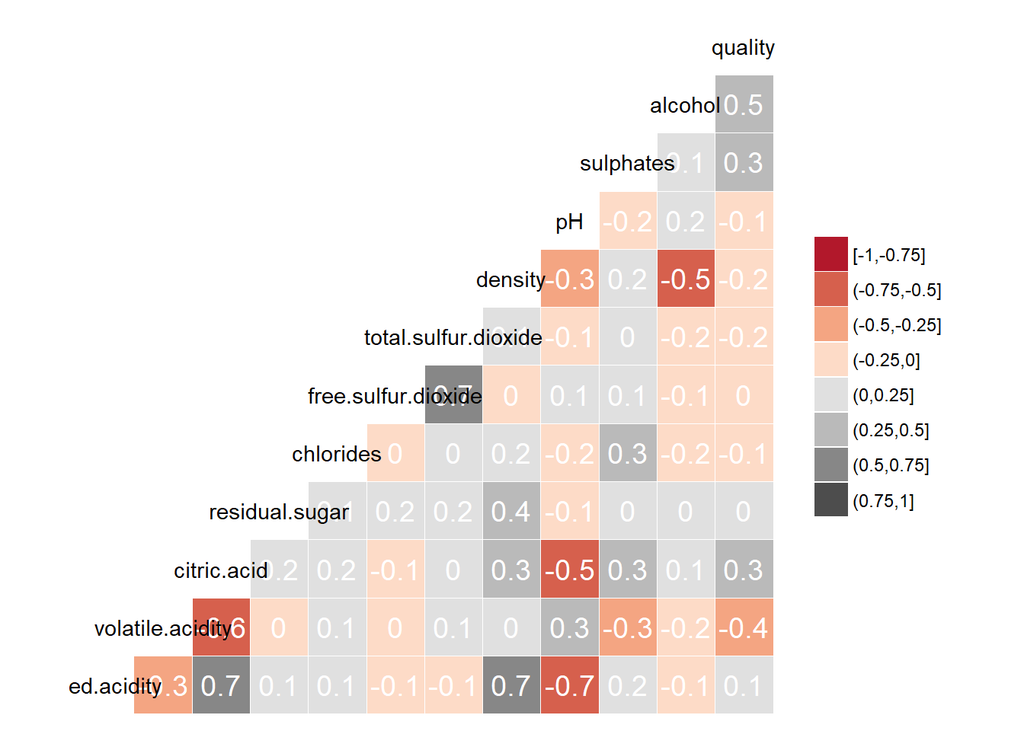

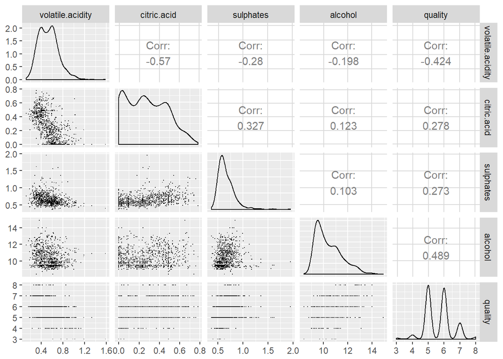

At the beginning, we use ggcorr to provide a rough overview of the correlations between the individual variables. We are particularly interested in what the quality of the wines.

After a look at our overview it becomes clear that the quality shows with others values have hardly any stronger correlations. Only for the alcohol content (corr 0.5) and for the proportion The volatile acidity (correlation of 0.4) shows stronger correlations. Compound s still exist between quality and sulphur as well as quality and citric acid (each 0.3).  
We assume that with values of +/- 0.3 significant correlations exist, with values between 0.4 and 0.6 of strong correlations can be spoken and values above +/- 0.7 are very high. strong correlations. The latter, however, come in our record not before.

With ggpairs we then look at some values with strong correlation still a little more precisely. These pairs of variables are now to be examined in more detail.

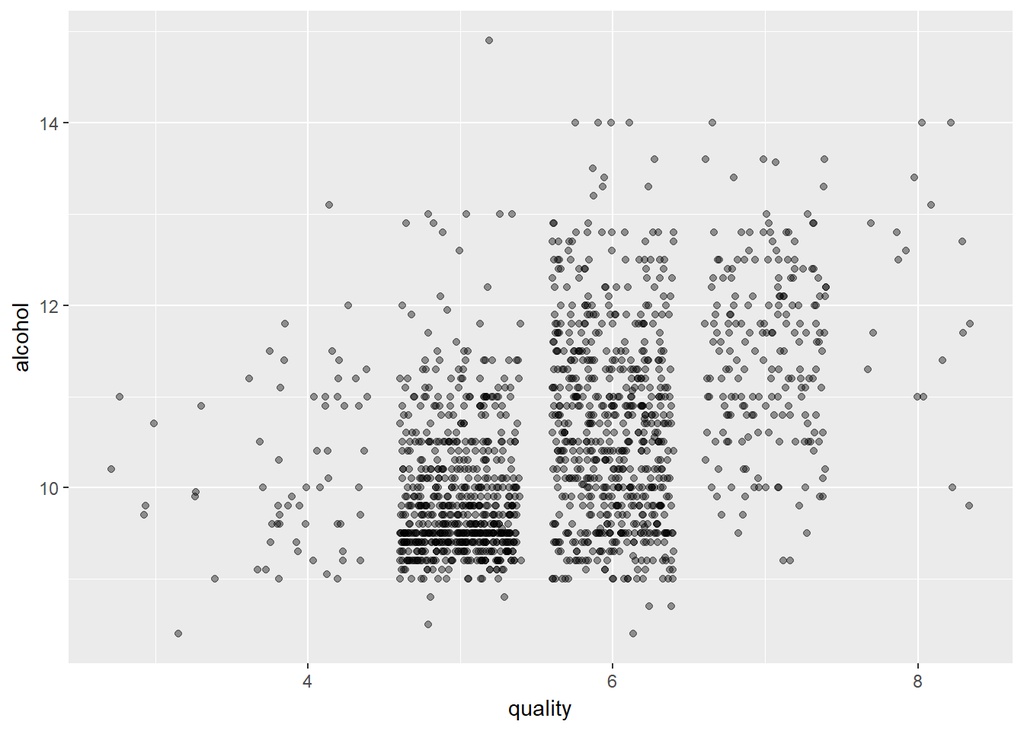

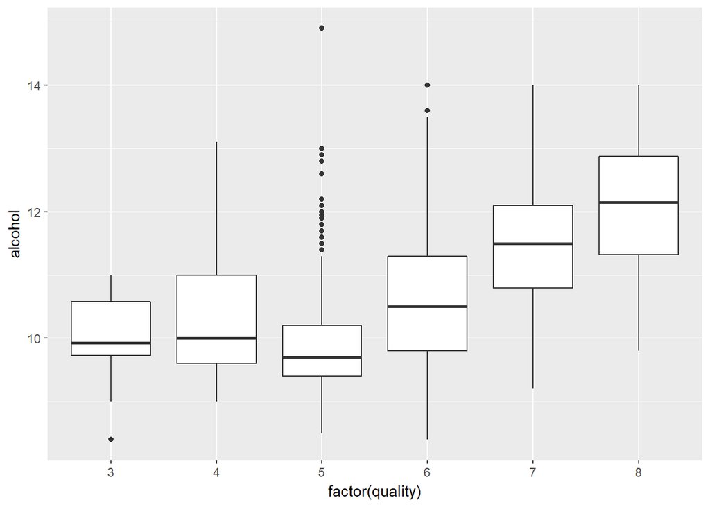

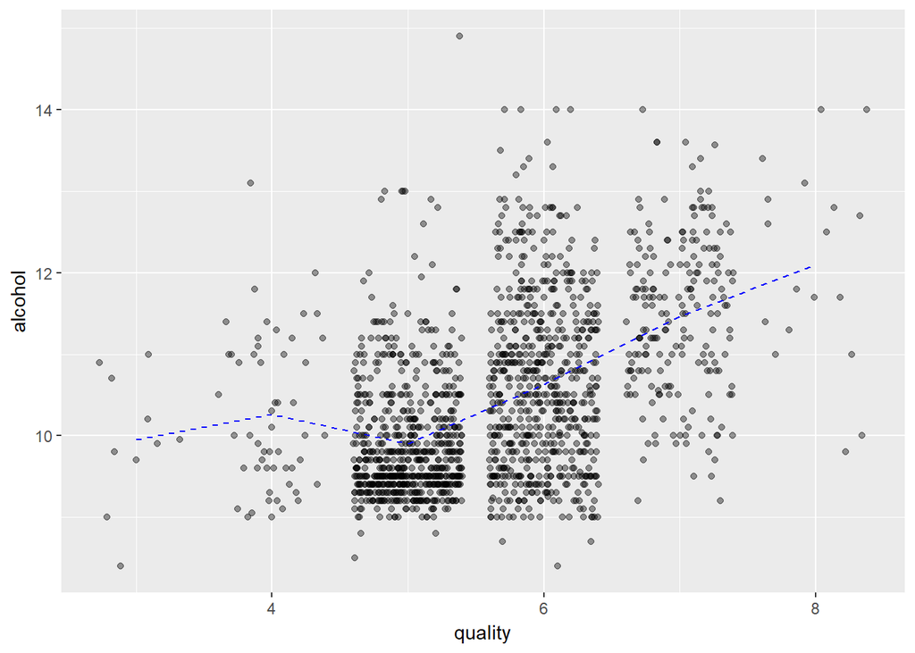

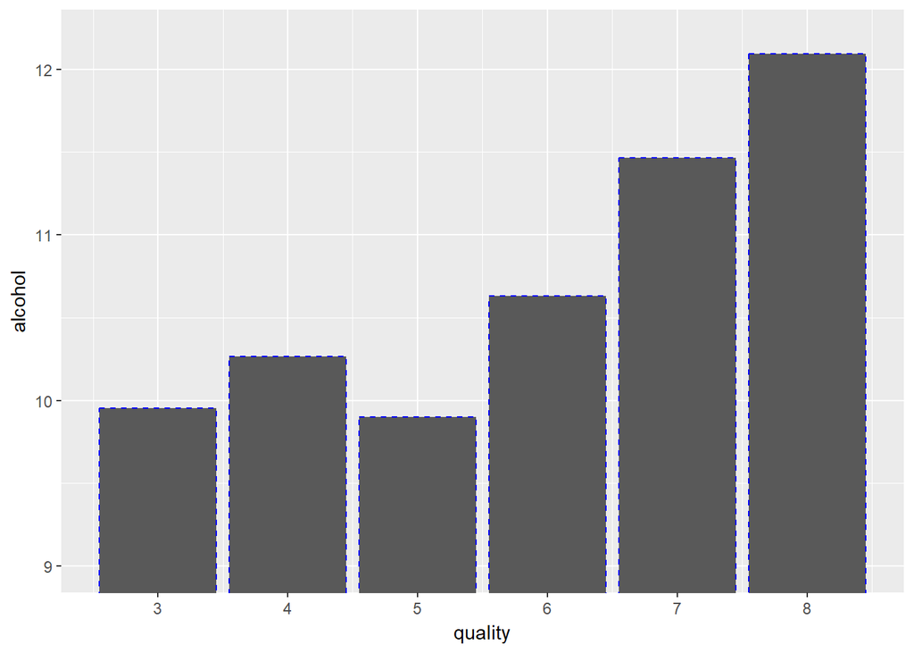

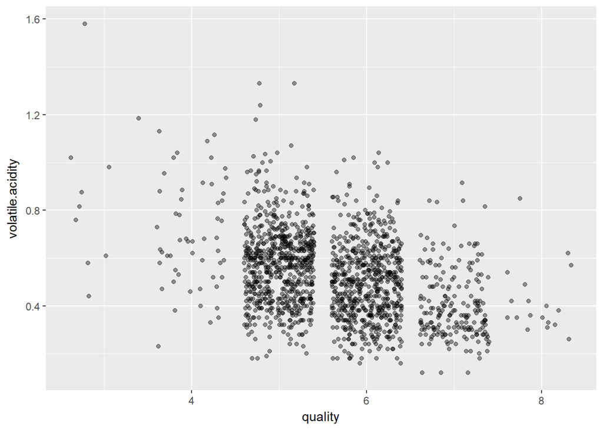

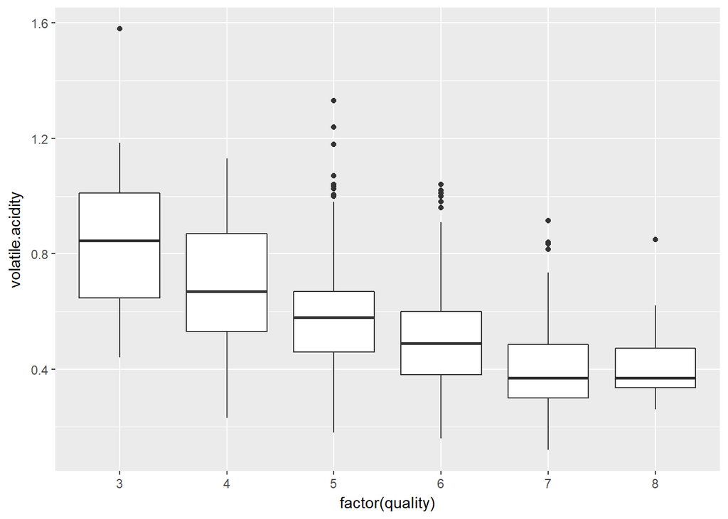

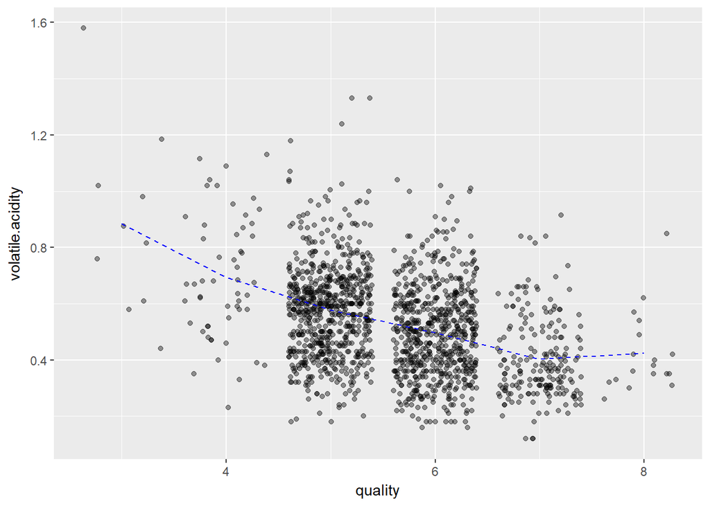

In principle, the wines of higher quality show less **volatile acidity** than the wines of the lower quality classes. This was to be expected, because acidity can give the wine a vinegar taste. The fact that some wines with a high proportion nevertheless slip into the higher quality classes could indicate that some testers certainly appreciate the high proportion of volatile acidity as a special note of the wine.

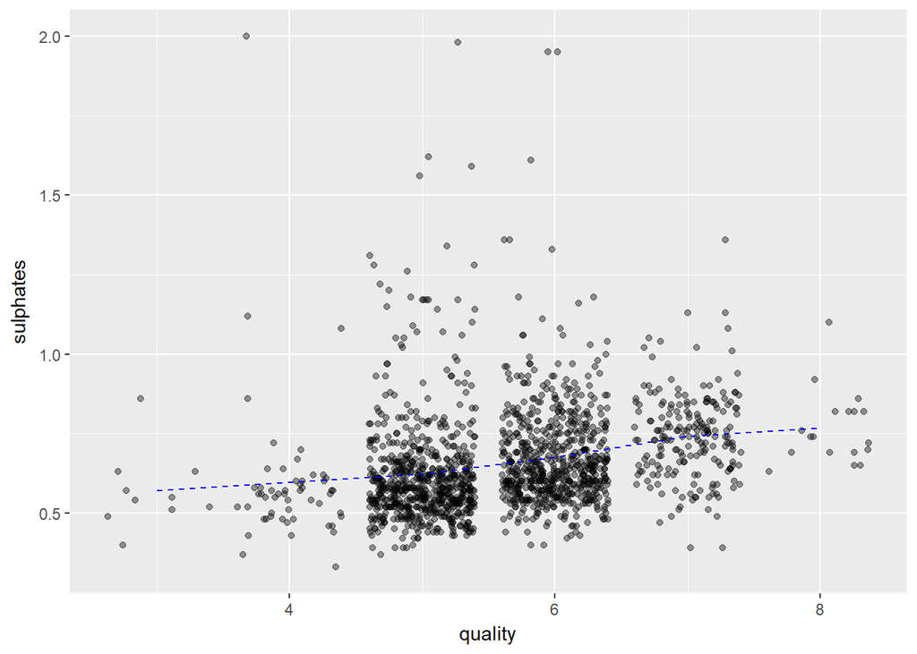

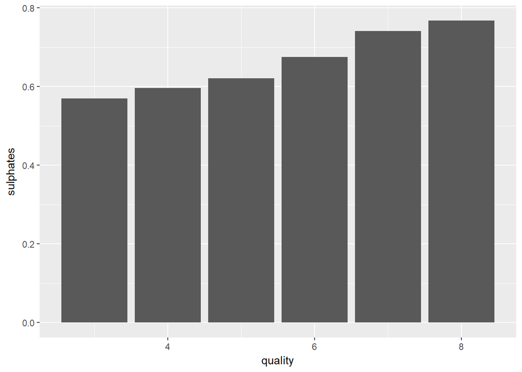

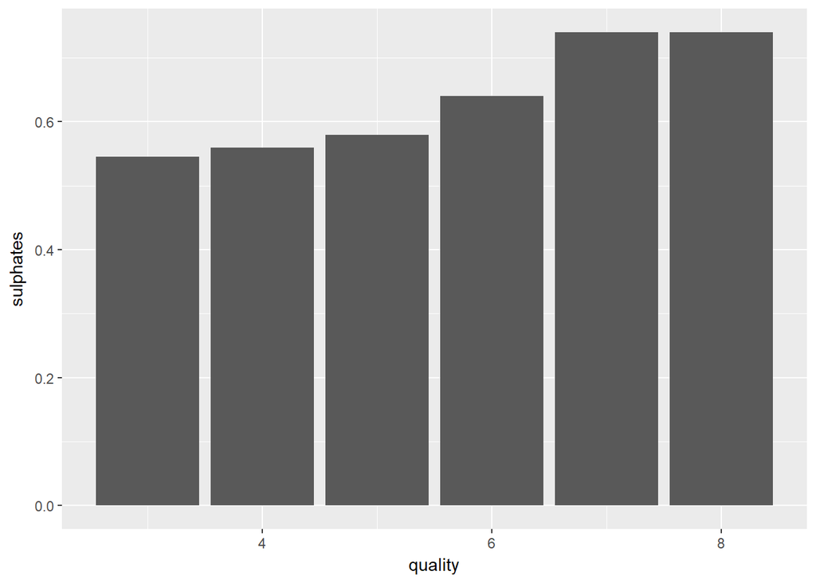